# LBB_RM

Fikri K Rizal

2022-08-22

Tingkat Kejahatan di suatu daerah, dipengaruhi oleh banyak faktor. Berikut adalah analisisi Tingkat Kejahatan di US berdasarkan beberapa variable sosio-demografi.

Menggunakan Analisis Regresi Linier untuk menganalisis dan memprediksi Tingkat Kejahatan, sehingga bisa mengurangi Tingkat Kejahatan dengan memperbaiki variabel-variabel yang memiliki pengaruh signifikan.

# **Data Preparation**

## **Load Library yang dibutuhkan**

```r
library(GGally)
library(lmtest)
library(car)
library(dplyr)
library(MLmetrics)
```

## **Load dataset**

```r
crime <- read.csv("Data Input/crime.csv")
```

Berikut adalah keterangan dari setiap kolom:

- `percent_m`: Persentase laki-laki berusia 14-24
- `is_south`: Apakah berada di negara bagian selatan? 1 untuk Iya, 0 untuk Tidak.
- `mean_education`: Rata-rata tahun sekolah
- `police_exp60`: Pengeluaran polisi pada tahun 1960
- `police_exp59`: Pengeluaran polisi pada tahun 1959
- `labour_participation`: Tingkat partisipasi kerja
- `m_per1000f`: Jumlah laki-laki dibandingkan setiap 1000 perempuan
- `state_pop`: Populasi negara bagian
- `nonwhites_per1000`: Jumlah penduduk non-kulit putih per 1000 orang
- `unemploy_m24`: Tingkat pengangguran laki-laki perkotaan berusia 14-24
- `unemploy_m39`: Tingkat pengangguran laki-laki perkotaan berusia 35-39
- `gdp`: Gross domestic product per kepala
- `inequality`: Ketimpangan pendapatan
- `prob_prison`: Kemungkinan dipenjara
- `time_prison`: Rata-rata waktu menjalani hukuman di Penjara
- `crime_rate`: Tingkat kejahatan dalam kategori yang tidak ditentukan

## **Explanatory Data Analysis**

### **Cek Data**

```r
glimpse(crime)
```

```
## Rows: 47
## Columns: 16
## $ percent_m            <int> 151, 143, 142, 136, 141, 121, 127, 131, 157, 140,…
## $ is_south             <int> 1, 0, 1, 0, 0, 0, 1, 1, 1, 0, 0, 0, 0, 0, 1, 1, 0…
## $ mean_education       <int> 91, 113, 89, 121, 121, 110, 111, 109, 90, 118, 10…
## $ police_exp60         <int> 58, 103, 45, 149, 109, 118, 82, 115, 65, 71, 121,…
## $ police_exp59         <int> 56, 95, 44, 141, 101, 115, 79, 109, 62, 68, 116, …
## $ labour_participation <int> 510, 583, 533, 577, 591, 547, 519, 542, 553, 632,…
## $ m_per1000f           <int> 950, 1012, 969, 994, 985, 964, 982, 969, 955, 102…
## $ state_pop            <int> 33, 13, 18, 157, 18, 25, 4, 50, 39, 7, 101, 47, 2…
## $ nonwhites_per1000    <int> 301, 102, 219, 80, 30, 44, 139, 179, 286, 15, 106…
## $ unemploy_m24         <int> 108, 96, 94, 102, 91, 84, 97, 79, 81, 100, 77, 83…
## $ unemploy_m39         <int> 41, 36, 33, 39, 20, 29, 38, 35, 28, 24, 35, 31, 2…
## $ gdp                  <int> 394, 557, 318, 673, 578, 689, 620, 472, 421, 526,…
## $ inequality           <int> 261, 194, 250, 167, 174, 126, 168, 206, 239, 174,…
## $ prob_prison          <dbl> 0.084602, 0.029599, 0.083401, 0.015801, 0.041399,…
## $ time_prison          <dbl> 26.2011, 25.2999, 24.3006, 29.9012, 21.2998, 20.9…
## $ crime_rate           <int> 791, 1635, 578, 1969, 1234, 682, 963, 1555, 856, …
```

### **Mengubah Tipe Data**

```r
crime <- crime %>%
  mutate(is_south = as.factor(is_south))
glimpse(crime)
```

```
## Rows: 47
## Columns: 16
## $ percent_m            <int> 151, 143, 142, 136, 141, 121, 127, 131, 157, 140,…
## $ is_south             <fct> 1, 0, 1, 0, 0, 0, 1, 1, 1, 0, 0, 0, 0, 0, 1, 1, 0…
## $ mean_education       <int> 91, 113, 89, 121, 121, 110, 111, 109, 90, 118, 10…
## $ police_exp60         <int> 58, 103, 45, 149, 109, 118, 82, 115, 65, 71, 121,…
## $ police_exp59         <int> 56, 95, 44, 141, 101, 115, 79, 109, 62, 68, 116, …
## $ labour_participation <int> 510, 583, 533, 577, 591, 547, 519, 542, 553, 632,…
## $ m_per1000f           <int> 950, 1012, 969, 994, 985, 964, 982, 969, 955, 102…
## $ state_pop            <int> 33, 13, 18, 157, 18, 25, 4, 50, 39, 7, 101, 47, 2…
## $ nonwhites_per1000    <int> 301, 102, 219, 80, 30, 44, 139, 179, 286, 15, 106…
## $ unemploy_m24         <int> 108, 96, 94, 102, 91, 84, 97, 79, 81, 100, 77, 83…
## $ unemploy_m39         <int> 41, 36, 33, 39, 20, 29, 38, 35, 28, 24, 35, 31, 2…
## $ gdp                  <int> 394, 557, 318, 673, 578, 689, 620, 472, 421, 526,…
## $ inequality           <int> 261, 194, 250, 167, 174, 126, 168, 206, 239, 174,…
## $ prob_prison          <dbl> 0.084602, 0.029599, 0.083401, 0.015801, 0.041399,…
## $ time_prison          <dbl> 26.2011, 25.2999, 24.3006, 29.9012, 21.2998, 20.9…
## $ crime_rate           <int> 791, 1635, 578, 1969, 1234, 682, 963, 1555, 856, …
```

### **Cek Missing Value**

```r
sum(is.na(crime))
```

```
## [1] 0
```

Karena tidak ada missing value, maka bisa dilanjutkan ke tahapan selanjutnya.

### **Cek Korelasi antar Variabel**

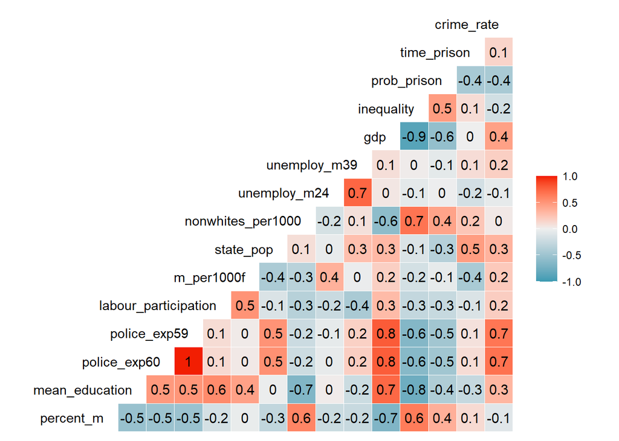

```r
ggcorr(crime, label = TRUE, hjust = 1, layout.exp = 2)
```

Dari grafik korelasi diatas, variabel-variabel yang ada, memiliki pengaruh positif dan negatif terhadap *crime_rate*. Untuk variabel *police_exp59* dan *police_exp60* memiliki korelasi paling tinggi diantara yang lain dan variabel *nonwhites_per1000* bisa dikatakan tidak memiliki korelasi sama sekali. Akan tetapi dari variabel *police_exp59* dan *police_exp60* keduanya memiliki korelasi yang sangat kuat, maka cukup diambil salah satu dari kedua variabel tersebut.

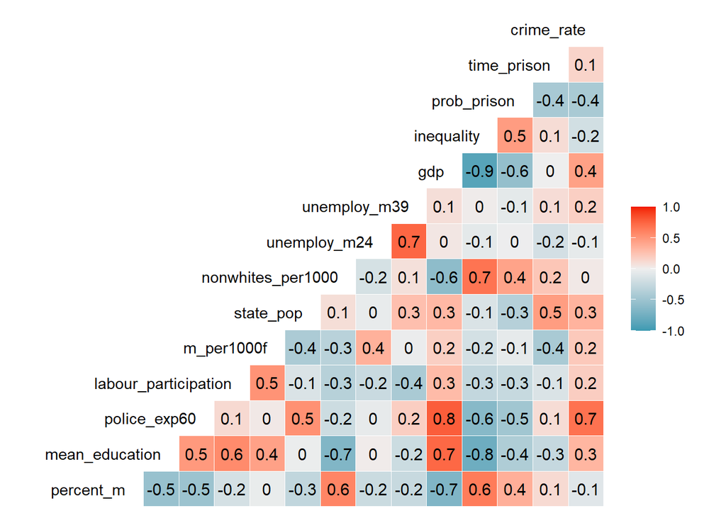

```r
crime <- crime %>%
  select(-police_exp59)

ggcorr(crime, label = TRUE, hjust = 1, layout.exp = 2)
```

# **Pembuatan Model Regresi Linear**

Tahapan selanjutnya adalah pembuatan model regresi linear dengan variabel-variabel prediktor yang ada. Model yang dibuat terdiri dari beberapa model yang menggunakan prediktor berbeda.

## **Model dengan 1 Prediktor**

Untuk membuat model dengan 1 prediktor, kita gunakan variabel dengan korelasi paling tinggi dan yang dipakai adalah variabel *police_exp60*.

```r
m1 <- lm(crime_rate~police_exp60, crime)
m1
```

```
##
## Call:
## lm(formula = crime_rate ~ police_exp60, data = crime)
##
## Coefficients:
##  (Intercept)  police_exp60
##      144.464         8.948
```

```r
summary(m1)
```

```
##
## Call:
## lm(formula = crime_rate ~ police_exp60, data = crime)
##
## Residuals:
##     Min      1Q  Median      3Q     Max
## -586.91 -155.63   32.52  139.58  568.84
##
## Coefficients:
##              Estimate Std. Error t value Pr(>|t|)
## (Intercept)   144.464    126.693   1.140     0.26
## police_exp60    8.948      1.409   6.353 9.34e-08 ***
## ---
## Signif. codes:  0 '***' 0.001 '**' 0.01 '*' 0.05 '.' 0.1 ' ' 1
##
## Residual standard error: 283.9 on 45 degrees of freedom
## Multiple R-squared:  0.4728, Adjusted R-squared:  0.4611
## F-statistic: 40.36 on 1 and 45 DF,  p-value: 9.338e-08
```

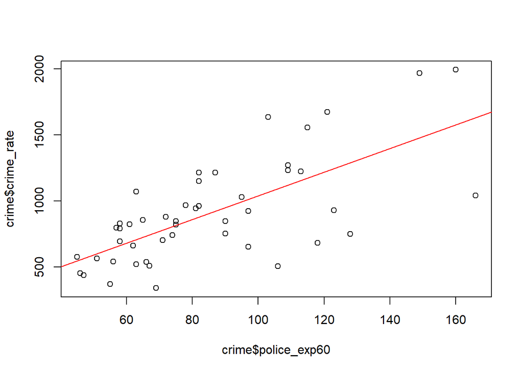

```r
plot(crime$police_exp60, crime$crime_rate)
abline(m1$coefficients[1],m1$coefficients[2], col="red")
```

Dari model diatas, dapat dilihat nilai adjuster R-squared adalah 0.4611.

## **Model dengan Semua Variable Prediktor**

Dari model pertama, nilai dari ajusted R-squared masih cukup rendah, sehingga diperlukan model lain untuk mendapat nilai adjusted R-squared yang lebih baik.

```r
m2 <- lm(crime_rate ~ ., crime)
m2
```

```
##
## Call:
## lm(formula = crime_rate ~ ., data = crime)
##
## Coefficients:
##          (Intercept)             percent_m             is_south1
##           -6379.0457                8.9861                5.6688
##       mean_education          police_exp60  labour_participation
##              17.7304                9.6526               -0.2801
##           m_per1000f             state_pop     nonwhites_per1000
##               1.8218               -0.7836                0.2446
##         unemploy_m24          unemploy_m39                   gdp
##              -5.4163               16.9362                0.9072
##           inequality           prob_prison           time_prison
##               7.2708            -4285.1992               -1.1276
```

```r
summary(m2)
```

```
##
## Call:
## lm(formula = crime_rate ~ ., data = crime)
##
## Residuals:
##     Min      1Q  Median      3Q     Max
## -442.55 -116.46    8.86  118.26  473.49
##
## Coefficients:
##                        Estimate Std. Error t value Pr(>|t|)
## (Intercept)          -6379.0457  1568.9382  -4.066 0.000291 ***
## percent_m                8.9861     4.1571   2.162 0.038232 *
## is_south1                5.6688   148.0997   0.038 0.969705
## mean_education          17.7304     6.0824   2.915 0.006445 **
## police_exp60             9.6526     2.3921   4.035 0.000317 ***
## labour_participation    -0.2801     1.4079  -0.199 0.843538
## m_per1000f               1.8218     2.0293   0.898 0.376026
## state_pop               -0.7836     1.2857  -0.609 0.546523
## nonwhites_per1000        0.2446     0.6187   0.395 0.695239
## unemploy_m24            -5.4163     4.1784  -1.296 0.204164
## unemploy_m39            16.9362     8.2148   2.062 0.047441 *
## gdp                      0.9072     1.0329   0.878 0.386292
## inequality               7.2708     2.2564   3.222 0.002921 **
## prob_prison          -4285.1992  2183.8679  -1.962 0.058484 .
## time_prison             -1.1276     6.6919  -0.168 0.867251
## ---
## Signif. codes:  0 '***' 0.001 '**' 0.01 '*' 0.05 '.' 0.1 ' ' 1
##
## Residual standard error: 208.6 on 32 degrees of freedom
## Multiple R-squared:  0.7976, Adjusted R-squared:  0.709
## F-statistic: 9.006 on 14 and 32 DF,  p-value: 1.673e-07
```

Dari model menggunakan semua variabel prediktor, diperoleh nilai adjuster R-squared yang lebih baik yaitu 0.709.

## **Model dengan Menggunakan Step-Wise *backward***

Model dengan semua variabel prediktor memang lebih baik dibandingkan dengan 1 variabel prediktor, akan tetapi perlu dipastikan juga model lain yang mungkin memiliki adjusted R-squared yang lebih baik.

```r
m_step <- step(m2, direction = "backward")
```

```
## Start:  AIC=513.95
## crime_rate ~ percent_m + is_south + mean_education + police_exp60 +
##     labour_participation + m_per1000f + state_pop + nonwhites_per1000 +
##     unemploy_m24 + unemploy_m39 + gdp + inequality + prob_prison +
##     time_prison
##
##                        Df Sum of Sq     RSS    AIC
## - is_south              1        64 1392929 511.95
## - time_prison           1      1236 1394101 511.99
## - labour_participation  1      1723 1394588 512.00
## - nonwhites_per1000     1      6802 1399667 512.18
## - state_pop             1     16168 1409033 512.49
## - gdp                   1     33582 1426447 513.07
## - m_per1000f            1     35080 1427945 513.12
## <none>                              1392865 513.95
## - unemploy_m24          1     73136 1466001 514.35
## - prob_prison           1    167590 1560455 517.29
## - unemploy_m39          1    185009 1577874 517.81
## - percent_m             1    203389 1596254 518.35
## - mean_education        1    369864 1762729 523.01
## - inequality            1    451937 1844802 525.15
## - police_exp60          1    708738 2101603 531.28
##
## Step:  AIC=511.95
## crime_rate ~ percent_m + mean_education + police_exp60 + labour_participation +
##     m_per1000f + state_pop + nonwhites_per1000 + unemploy_m24 +
##     unemploy_m39 + gdp + inequality + prob_prison + time_prison
##
##                        Df Sum of Sq     RSS    AIC
## - time_prison           1      1319 1394247 509.99
## - labour_participation  1      2646 1395574 510.04
## - nonwhites_per1000     1      8949 1401878 510.25
## - state_pop             1     16166 1409095 510.49
## - gdp                   1     36125 1429054 511.15
## - m_per1000f            1     36467 1429396 511.16
## <none>                              1392929 511.95
## - unemploy_m24          1     86999 1479928 512.80
## - prob_prison           1    171381 1564310 515.40
## - unemploy_m39          1    196372 1589301 516.15
## - percent_m             1    206121 1599050 516.43
```

[output cut: 76 more lines]

```
##
## Step:  AIC=503.93
## crime_rate ~ percent_m + mean_education + police_exp60 + m_per1000f +
##     unemploy_m24 + unemploy_m39 + inequality + prob_prison
##
##                  Df Sum of Sq     RSS    AIC
## <none>                        1453068 503.93
## - m_per1000f      1    103159 1556227 505.16
## - unemploy_m24    1    127044 1580112 505.87
## - prob_prison     1    247978 1701046 509.34
## - unemploy_m39    1    255443 1708511 509.55
## - percent_m       1    296790 1749858 510.67
## - mean_education  1    445788 1898855 514.51
## - inequality      1    738244 2191312 521.24
## - police_exp60    1   1672038 3125105 537.93
```

```r
m_step
```

```
##
## Call:
## lm(formula = crime_rate ~ percent_m + mean_education + police_exp60 +
##     m_per1000f + unemploy_m24 + unemploy_m39 + inequality + prob_prison,
##     data = crime)
##
## Coefficients:
##    (Intercept)       percent_m  mean_education    police_exp60      m_per1000f
##      -6426.101           9.332          18.012          10.265           2.234
##   unemploy_m24    unemploy_m39      inequality     prob_prison
##         -6.087          18.735           6.133       -3796.032
```

```r
summary(m_step)
```

```
##
## Call:
## lm(formula = crime_rate ~ percent_m + mean_education + police_exp60 +
##     m_per1000f + unemploy_m24 + unemploy_m39 + inequality + prob_prison,
##     data = crime)
##
## Residuals:
##     Min      1Q  Median      3Q     Max
## -444.70 -111.07    3.03  122.15  483.30
##
## Coefficients:
##                 Estimate Std. Error t value Pr(>|t|)
## (Intercept)    -6426.101   1194.611  -5.379 4.04e-06 ***
## percent_m          9.332      3.350   2.786  0.00828 **
## mean_education    18.012      5.275   3.414  0.00153 **
## police_exp60      10.265      1.552   6.613 8.26e-08 ***
## m_per1000f         2.234      1.360   1.642  0.10874
## unemploy_m24      -6.087      3.339  -1.823  0.07622 .
## unemploy_m39      18.735      7.248   2.585  0.01371 *
## inequality         6.133      1.396   4.394 8.63e-05 ***
## prob_prison    -3796.032   1490.646  -2.547  0.01505 *
## ---
## Signif. codes:  0 '***' 0.001 '**' 0.01 '*' 0.05 '.' 0.1 ' ' 1
##
## Residual standard error: 195.5 on 38 degrees of freedom
## Multiple R-squared:  0.7888, Adjusted R-squared:  0.7444
## F-statistic: 17.74 on 8 and 38 DF,  p-value: 1.159e-10
```

Dengan menggunakan metode step-wise regression, kita dapat memperoleh model terbaik berdasarkan nilai AIC yang paling rendah.

Dari ketiga model yang telah dibuat, nilai adjusted R dari model yang menggunakan step-wise reggresion memberikan nilai paling besar yaitu 0.7444 dibandingkan 0.4611 pada model 1 prediktor dan 0.709 pada model dengan semua prediktor.

# **Evaluasi Model**

```r
data_eval <- data.frame(aktual = crime$crime_rate, pred_m1 = m1$fitted.values, pred_m_step = m_step$fitted.values)
```

## **Mean Absolute Error (MAE)**

MAE dari model m1

```r
MAE(y_pred = data_eval$pred_m1 , y_true = data_eval$aktual)
```

```
## [1] 218.298
```

MAE dari model m_step

```r
MAE(y_pred = data_eval$pred_m_step , y_true = data_eval$aktual)
```

```
## [1] 138.6674
```

Dari kedua MAE yang telah dihitung, MAE model *m_step* lebih kecil dibandingkan model *m1*, akan tetapi kita tetap perlu membandingkan dengan range dari variabel target.

```r
range(crime$crime_rate)
```

```
## [1]  342 1993
```

## **Mean Absolute Percentage Error (MAPE)**

MAPE dari model m1

```r
MAPE(y_pred = data_eval$pred_m1 , y_true = data_eval$aktual)*100
```

```
## [1] 27.24177
```

MAPE dari model m_step

```r
MAPE(y_pred = data_eval$pred_m_step , y_true = data_eval$aktual)*100
```

```
## [1] 17.48751
```

## **Mean Squared Error (MSE)**

MSE dari model m1

```r
MSE(y_pred = data_eval$pred_m1 , y_true = data_eval$aktual)
```

```
## [1] 77183.53
```

MSE dari model m_step

```r
MSE(y_pred = data_eval$pred_m_step , y_true = data_eval$aktual)
```

```
## [1] 30916.34
```

## **Root Mean Squared Error (RMSE)**

RMSE dari model m1

```r
RMSE(y_pred = data_eval$pred_m1 , y_true = data_eval$aktual)
```

```
## [1] 277.8192
```

RMSE dari model m_step

```r
RMSE(y_pred = data_eval$pred_m_step , y_true = data_eval$aktual)
```

```
## [1] 175.8304
```

Dari semua perhitungan error, model *m_step* memiliki error yang lebih kecil dibandingkan model *m1*

# **Uji Asumsi**

Dari evaluasi yang telah dilakukan, maka model *m_step* merupakan model terbaik yang bisa diperoleh. Akan tetap perlu dilakukan uji asumsi untuk memastikan bahwa model *m_step* memenuhi **Best Linear Unbiased Estimator (BLUE) model**.

## **Normality of Residuals**

### Visualisasi histogram residual

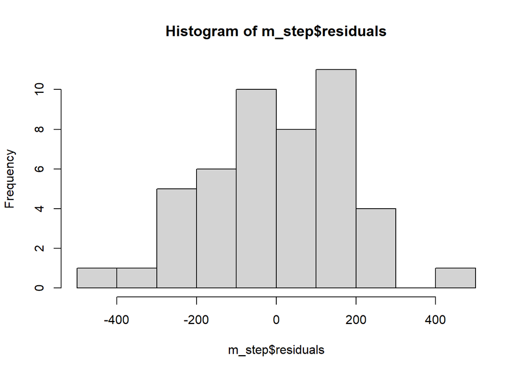

```r
hist(m_step$residuals)
```

### Uji statistik

Shapiro-Wilk hypothesis test:

- H0: error berdistribusi normal
- H1: error TIDAK berdistribusi normal

> Kondisi yang diharapkan: H0

```r
shapiro.test(m_step$residuals)
```

```
##
##  Shapiro-Wilk normality test
##
## data:  m_step$residuals
## W = 0.98511, p-value = 0.8051
```

Nilai p-value > 0.05. Sehingga gagal tolak H0, disimpulkan bahwa residual dari model *m_step* sudah berdistribusi normal. Asumsi normality terpenuhi.

## **Homoscedasticity of Residuals**

### Visualisasi scatter plot: `fitted.values` vs `residuals`

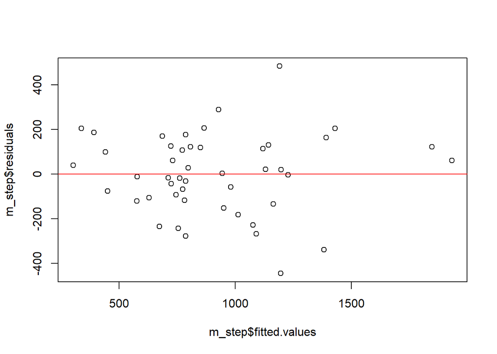

```r
plot(m_step$fitted.values, m_step$residuals)
abline(h=0, col="red")
```

### Uji statistik

Breusch-Pagan hypothesis test:

- H0: error menyebar konstan atau homoscedasticity
- H1: error menyebar TIDAK konstan atau heteroscedasticity

> Kondisi yang diharapkan: H0

```r
bptest(m_step)
```

```
##
##  studentized Breusch-Pagan test
##
## data:  m_step
## BP = 13.51, df = 8, p-value = 0.09546
```

Dari pengujian di atas, diketahui nilai p-value > 0.05. Sehingga gagal tolak H0, disimpulkan bahwa residual *m_step* sudah memenuhi asumsi homoskedastisitas.

## **No Multicollinearity**

Uji VIF (Variance Inflation Factor): * nilai VIF > 10: terjadi multicollinearity pada model * nilai VIF < 10: tidak terjadi multicollinearity pada model

```r
vif(m_step)
```

```
##      percent_m mean_education   police_exp60     m_per1000f   unemploy_m24
##       2.131963       4.189684       2.560496       1.932367       4.360038
##   unemploy_m39     inequality    prob_prison
##       4.508106       3.731074       1.381879
```

Dari nilai VIF di atas, dihasilkan nilai VIF <10 untuk keseluruhan variabel prediktor, sehingga asumsi no multicollinearity terpenuhi

Dari uji asumsi yang telah dilakukan, model *m_step* mememnuhi semua uji asumsi. Oleh karena itu model *m_step* merupakan model yang baik untuk digunakan,

# **Kesimpulan dan Saran**

```r
summary(m_step)$call
```

```
## lm(formula = crime_rate ~ percent_m + mean_education + police_exp60 +
##     m_per1000f + unemploy_m24 + unemploy_m39 + inequality + prob_prison,
##     data = crime)
```

Dari model *m_step* yang telah dibuat, bisa dilihat variabel-variabel yang mempengaruhi Tingkat Kejahatan yang terjadi. Diharapkan nilai-nilai pada variabel prediktor tersebut diperbaiki, sehingga bisa menekan angka tingkat kejahatan yang terjadi.